# STAT 4310 Final Project: Beauty data

## Model 4: Using Reduced Model

```r
mod4 <- summary(mod.red)
mod4
```

```
##
## Call:
## lm(formula = sqrt(wage) ~ exper + female + bigcity + educ + married +
##     belavg + union + smllcity, data = beauty_clean)
##
## Residuals:
##      Min       1Q   Median       3Q      Max
## -0.94836 -0.23722 -0.01169  0.24090  0.95141
##
## Coefficients:
##              Estimate Std. Error t value Pr(>|t|)
## (Intercept)  0.935239   0.069512  13.454  < 2e-16 ***
## exper        0.017166   0.001033  16.621  < 2e-16 ***
## female1     -0.454626   0.023746 -19.145  < 2e-16 ***
## bigcity1     0.324483   0.031887  10.176  < 2e-16 ***
## educ         0.083553   0.004653  17.955  < 2e-16 ***
## married1     0.069613   0.024842   2.802  0.00518 **
## belavg1     -0.140794   0.032703  -4.305 1.84e-05 ***
## union1       0.216177   0.024553   8.805  < 2e-16 ***
## smllcity1    0.133072   0.024516   5.428 7.27e-08 ***
## ---
## Signif. codes:  0 '***' 0.001 '**' 0.01 '*' 0.05 '.' 0.1 ' ' 1
##
## Residual standard error: 0.3288 on 935 degrees of freedom
## Multiple R-squared:  0.6272, Adjusted R-squared:  0.624
## F-statistic: 196.6 on 8 and 935 DF,  p-value: < 2.2e-16
```

The summary of the reduced model is identical to the summary of the transformed model. Although, the $R^2$ is not above 70% it’s the best it can do with the given predictors.

## Model 5: Interaction

As a last attempt, to increase the $R^2$ and $s$ we will try to include an interaction term between 2 predictors. We are looking at the interaction between the predictors female and married against the square root of hourly wage.

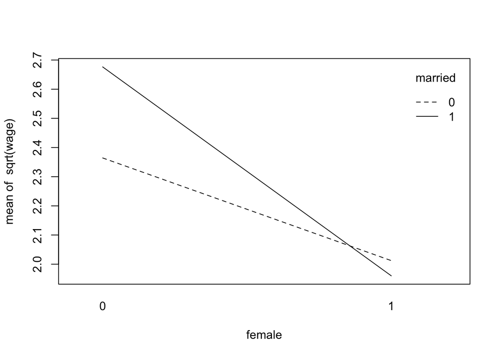

```r
#Interaction Plot
interaction.plot(female, married, sqrt(wage))
```

Based on the interaction plot, we can see that the lines intersect. This indicates an interaction.

```r
#Model with interaction
mod5 <- lm(sqrt(wage) ~ exper + female + bigcity + educ +
             married + belavg + union + smllcity + married*female, beauty_clean)
summary(mod5)
```

```
##
## Call:
## lm(formula = sqrt(wage) ~ exper + female + bigcity + educ + married +
##     belavg + union + smllcity + married * female, data = beauty_clean)
##
## Residuals:
##      Min       1Q   Median       3Q      Max
## -0.91671 -0.22844 -0.00635  0.24576  0.93761
##
## Coefficients:
##                   Estimate Std. Error t value Pr(>|t|)
## (Intercept)       0.899112   0.070727  12.712  < 2e-16 ***
## exper             0.016799   0.001040  16.158  < 2e-16 ***
## female1          -0.375247   0.039003  -9.621  < 2e-16 ***
## bigcity1          0.322317   0.031804  10.134  < 2e-16 ***
## educ              0.083045   0.004644  17.883  < 2e-16 ***
## married1          0.132288   0.034819   3.799 0.000154 ***
## belavg1          -0.136388   0.032651  -4.177 3.23e-05 ***
## union1            0.217194   0.024483   8.871  < 2e-16 ***
## smllcity1         0.131186   0.024454   5.364 1.02e-07 ***
## female1:married1 -0.125045   0.048826  -2.561 0.010592 *
## ---
## Signif. codes:  0 '***' 0.001 '**' 0.01 '*' 0.05 '.' 0.1 ' ' 1
##
## Residual standard error: 0.3279 on 934 degrees of freedom
## Multiple R-squared:  0.6298, Adjusted R-squared:  0.6262
## F-statistic: 176.5 on 9 and 934 DF,  p-value: < 2.2e-16
```

After including the interaction term, we achieve the highest $R^2$ at 62.98% and a low residual standard error of 0.3279.

```r
anova(mod3, mod5)
```

|  | Res.Df | RSS | Df | Sum of Sq | F | Pr(>F) |
| --- | --- | --- | --- | --- | --- | --- |
| 1 | 935 | 101.1062 | NA | NA | NA | NA |
| 2 | 934 | 100.4012 | 1 | 0.7050506 | 6.55886 | 0.01059245 |

Based on the ANOVA model, we are able to see that the interaction between an employee’s marital status and gender is significant in predicting the square root of their hourly wage. The P-value is 0.01059 which is below a significance level of 5%. The interaction term is needed in the linear regression model.

# Conclusion

After removing outliers and conducting 5 different models, we were able to achieve the highest $R^2$ at 62.98% by including an interaction term between the predictors married and female. This model used the square root of wage as a response based on our findings in the boxcox transformation. The remaining 8 predictors used in the model include: experience, female, big city, education, married, below average, union, and small city. The predictors in this model are able to explain the response, sqrt(wage), more accurately with this interaction term included. We suggest using other factors that impact an employee’s hourly wage in order to achieve a higher $R^2$.